# Reproducible Research: Peer Assessment 1

## Loading and preprocessing the data:

Below is the code used to import the data into r:

```r
activity_data <- read.csv("activity.csv", header = TRUE)
```

Afterwards, I ran the following code to sum the steps by date

```r
agg_steps <- aggregate(steps~date, data = activity_data, FUN = sum, na.rm=TRUE)
```

And here is a histogram showing the number of days that fall in a range of total steps

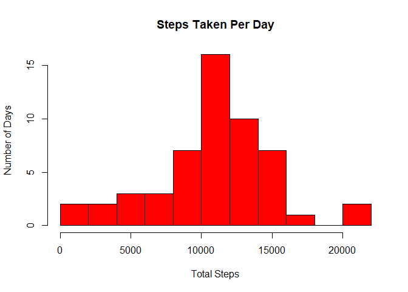

```r
hist(as.numeric(agg_steps$steps), breaks = 8,col="red",xlab="Total Steps",ylab="Number of Days", main="Steps Taken Per Day")
```

## What is mean total number of steps taken per day?

Below is the code used and results for the mean and median of total steps by day. As you can seem the mean is slightly higher than the median.

```r
mean(agg_steps$steps)
```

```
## [1] 10766.19
```

```r
median(agg_steps$steps)
```

```
## [1] 10765
```

## What is the average daily activity pattern?

In order to check the average daily activity pattern, I grouped the data by interval instead of date, with the below code:

```r
agg_interval <- aggregate(steps~interval, data = activity_data, FUN = mean, na.rm=TRUE)
```

Then plotted it with the following line chart. As the data moves from left to right, it progresses through the day:

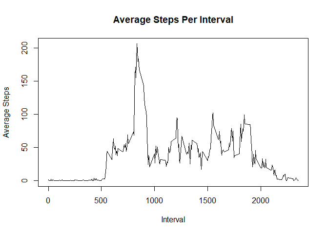

```r
plot(agg_interval$steps ~ agg_interval$interval, type = "l", xlab="Interval", ylab ="Average Steps", main = "Average Steps Per Interval")
```

Here is the code and results for the max interval:

```r
agg_interval[which.max(agg_interval$steps),]
```

```
##     interval    steps
## 104      835 206.1698
```

## Imputing missing values

Since NA values can sometimes throw data off, I tried to compensate a bit by replacing NAs with an average for that time interval (across all days). I used the following code:

```r
library(plyr)

#create column for interval average, and append it to dataset
activity_data <- ddply(activity_data,.(interval),transform,steps_avg = mean(steps, na.rm = TRUE))

#Replace NAs from step column with value from new interval average column
activity_data$steps[is.na(activity_data$steps)] <- activity_data$steps_avg[is.na(activity_data$steps)]
```

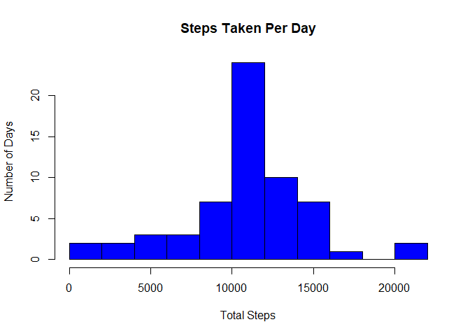

```r
agg_steps_rep <- aggregate(steps~date, data = activity_data, FUN = sum, na.rm=TRUE)

hist(as.numeric(agg_steps_rep$steps), breaks = 8,col="blue",xlab="Total Steps",ylab="Number of Days", main="Steps Taken Per Day")
```

And the mean is now equal to the median:

```r
mean(agg_steps_rep$steps)
```

```
## [1] 10766.19
```

```r
median(agg_steps_rep$steps)
```

```
## [1] 10766.19
```

## Are there differences in activity patterns between weekdays and weekends?

To compare weekday and weekend activity, I first used dplyr to add a day type column:

```r
library(dplyr)
activity_data$day = weekdays(as.Date(activity_data$date))

activity_data$day_type <-
    case_when(activity_data$day == "Monday" ~ "weekday",
              activity_data$day == "Tuesday" ~ "weekday",
              activity_data$day == "Wednesday" ~ "weekday",
              activity_data$day == "Thursday" ~ "weekday",
              activity_data$day == "Friday" ~ "weekday",
              activity_data$day == "Saturday" ~ "weekend",
              activity_data$day == "Sunday" ~ "weekend")
```

I then created seperate datasets for each, and plotted them on the same graph:

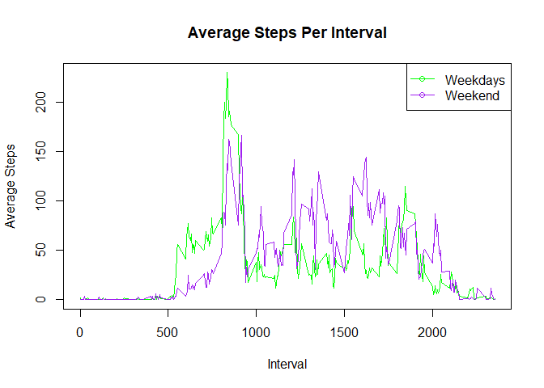

```r
activity_data_weekday <- activity_data[activity_data$day_type == "weekday",]

activity_data_weekend <- activity_data[activity_data$day_type == "weekend",]

agg_interval_weekday <- aggregate(steps~interval, data = activity_data_weekday, FUN = mean, na.rm=TRUE)

agg_interval_weekend <- aggregate(steps~interval, data = activity_data_weekend, FUN = mean, na.rm=TRUE)

plot(agg_interval_weekday$steps ~ agg_interval_weekday$interval, type = "l", xlab="Interval", ylab ="Average Steps", main = "Average Steps Per Interval", col="green")
lines(agg_interval_weekend$steps ~ agg_interval_weekend$interval, col="purple")
legend("topright",pch=1,col=c("green","purple"), lty=1,legend = c("Weekdays","Weekend"))
```